# IE-582 Homework-1: Evaluation of Bookmaker Performances

### Plots of the selected bookmakers.

#### Pinnacle Graphs- Based on Initial and Final odds

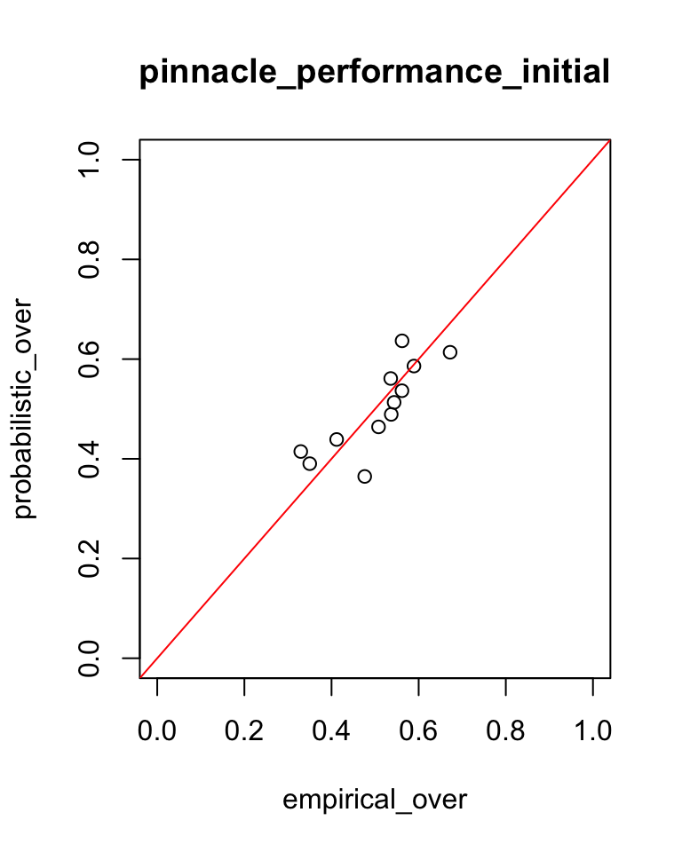

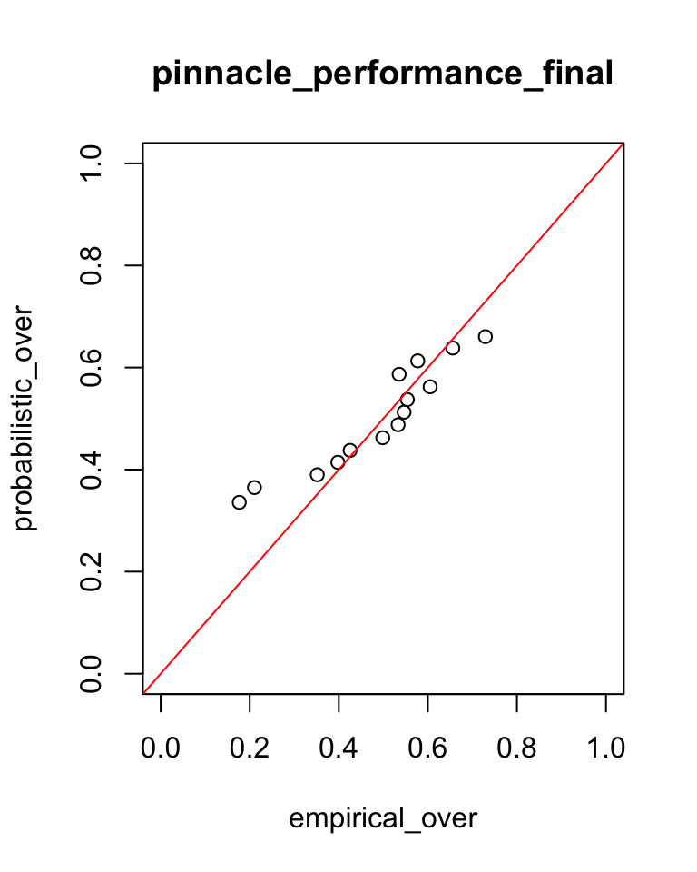

The points are around x=y line which mean the bookmaker is good at determining odds but the initial odds are more dispersed than the final odds. They improved their ability to predict the result in the final odds. As can be seen on the graph they are mostly near x=y line

#### bwin Graphs- Based on Initial and Final odds

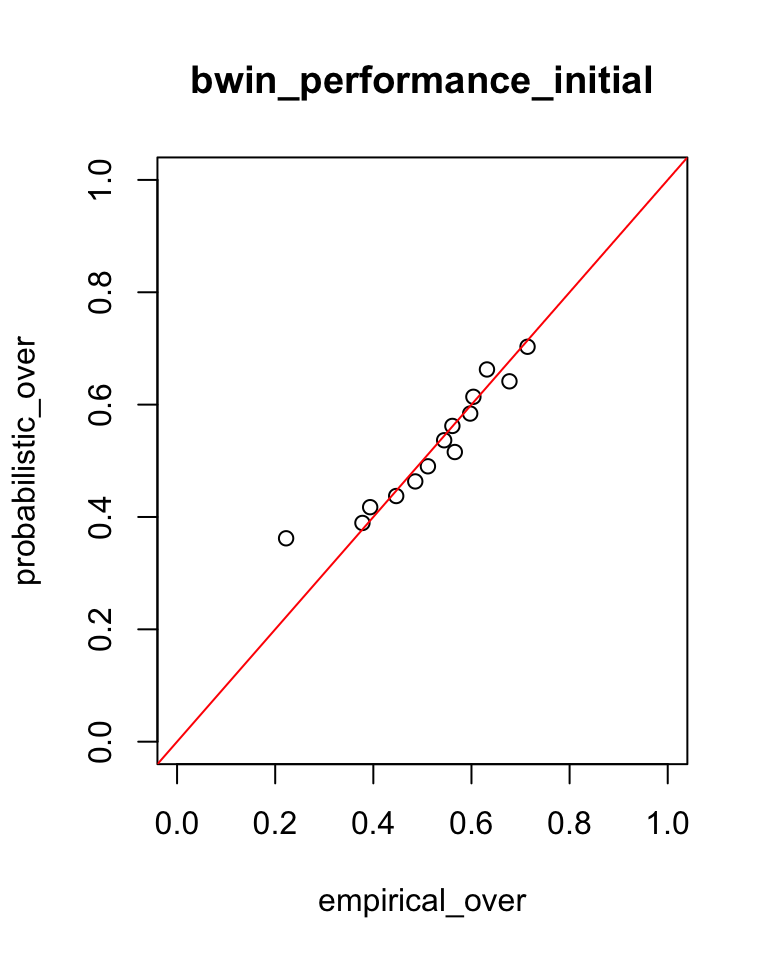

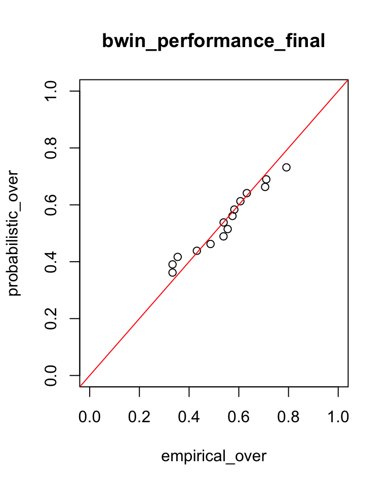

#### Betsafe Graphs- Based on Initial and Final odds

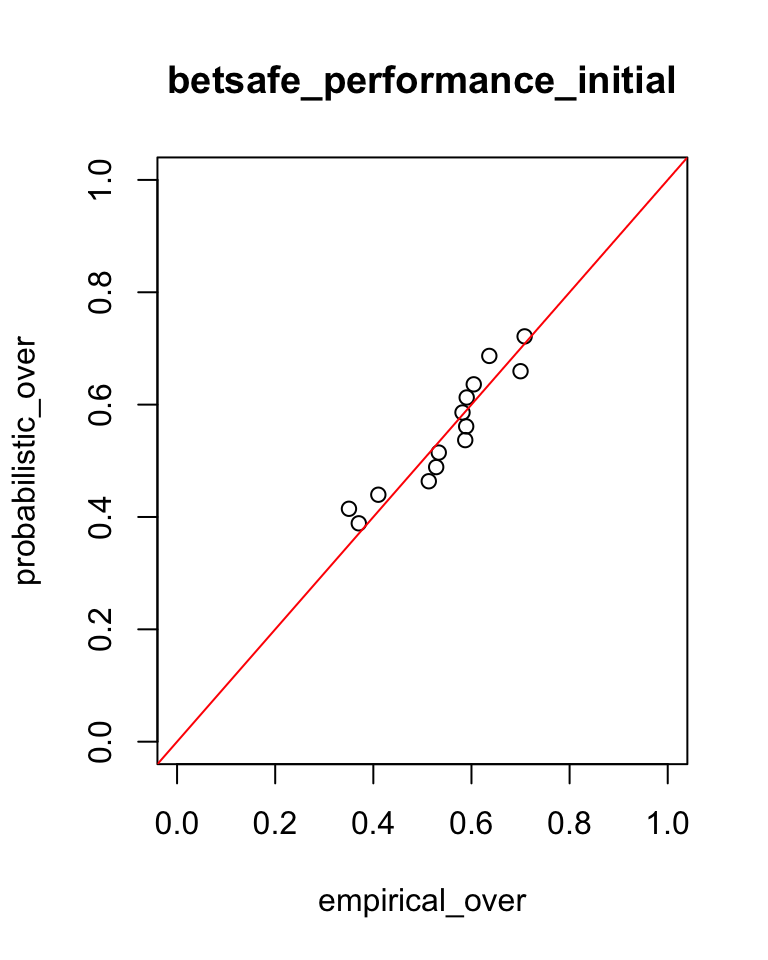

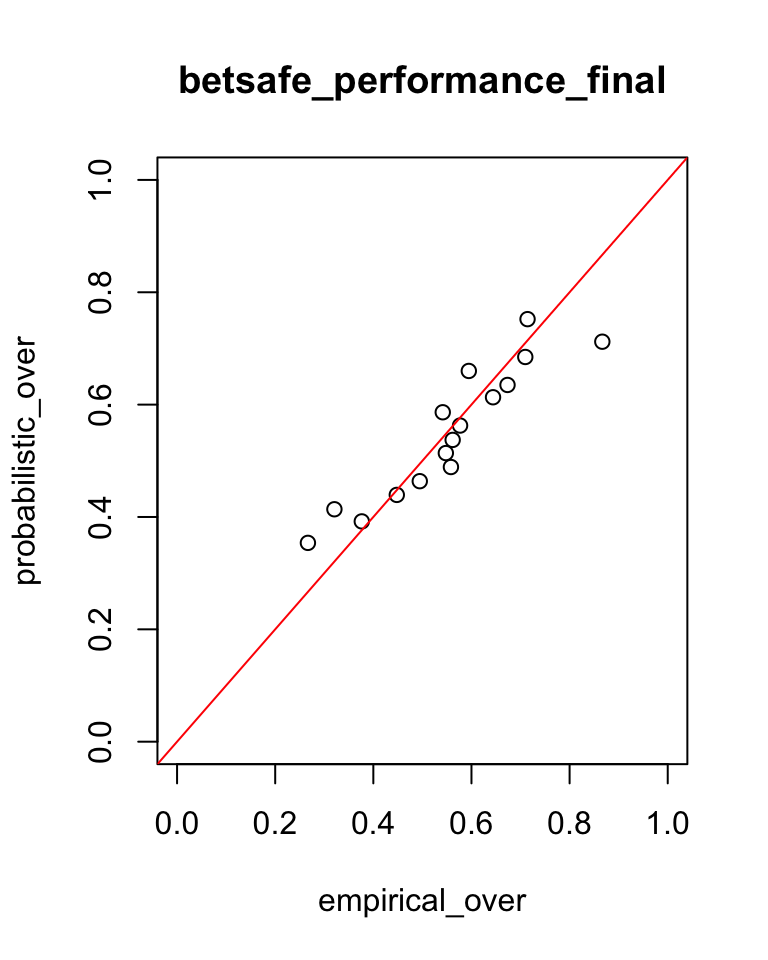

The betsafe’s initial predictions are better than their final ones. Because they are more in line with x=y line. There is no big difference between initial and final odds.

#### Unibet Graphs- Based on Initial and Final odds

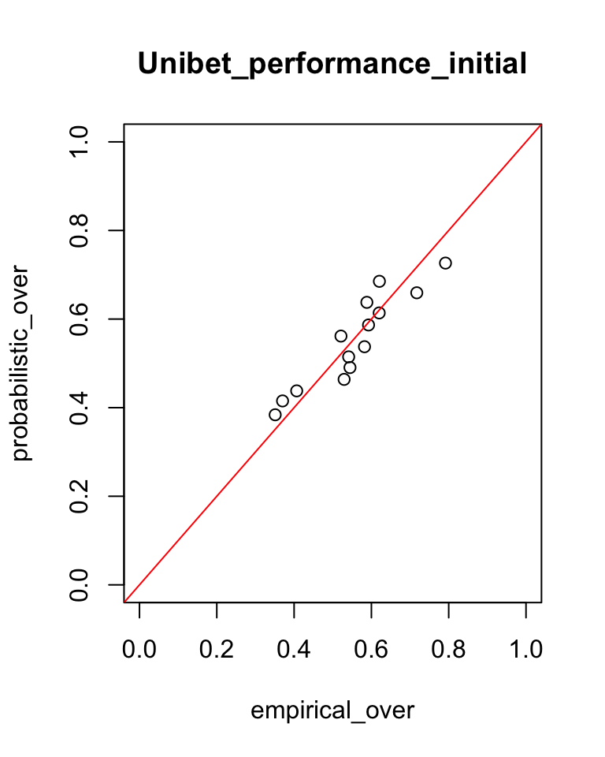

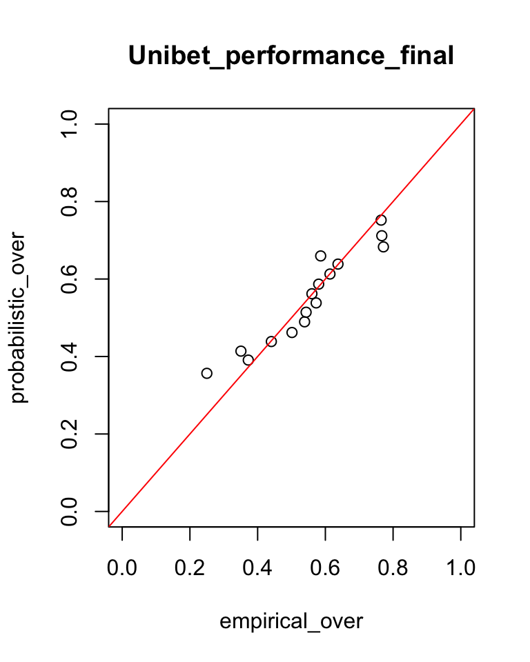

Unibet performance is mostly better in final odds than the initial odds, but they still have problems with bins around 0.4 and 0.8 because they are not in line with x=y.

#### youwin Graphs- Based on Initial and Final odds

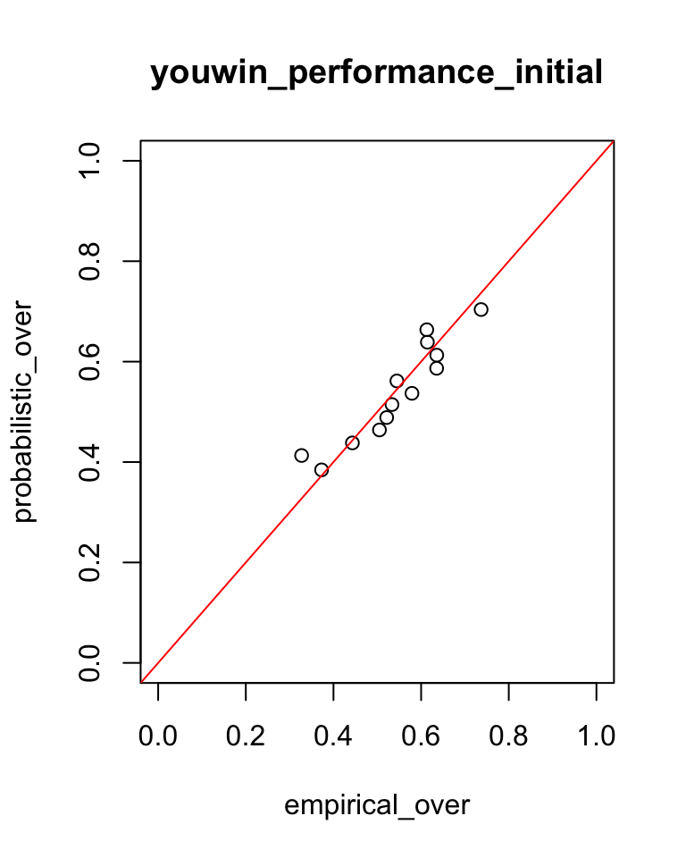

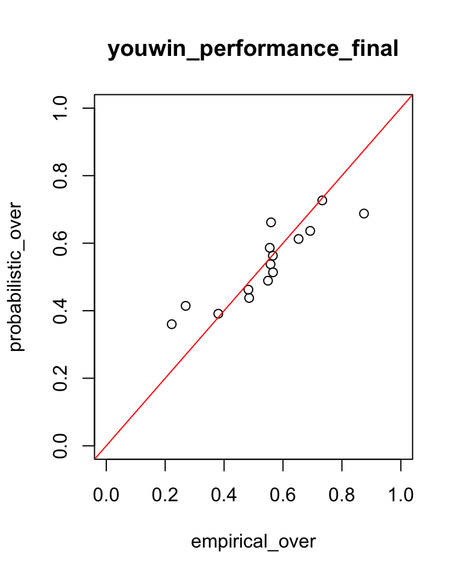

Youwin was better at prediction when we look from initial odds perspective, but their predictions are worsened with final odds. As you can see there are more deviations on the final graph.

## Task1.b Is betsafe good at determining over probabilities given time period

Bins are created, and some bins are merged based on over probabilities and distribution of the number of matches

```r
odd_cut_year=seq(0,1,0.05)
odd_cut_year=odd_cut_year[-c(9,15)]
odd_cut_year=odd_cut_year[-c(8,14)]
odd_cut_year
merged_matches_betsafe_part_b[,odd_cut_year:=cut(prob_over,odd_cut_year)]
```

Summary table is created to have the probabilities by years and bins on the same table, so we can perform the operations needed. And the data is sorted based on years and bins.

```r
summary_table_betsafe_over_years=merged_matches_betsafe_part_b[,list(empirical_over=mean(IsOver),
                                                       probabilistic_over=mean(prob_over),.N),
                                                               by=list(Year,odd_cut_year)]

summary_table_betsafe_over_years=summary_table_betsafe_over_years[order(Year,odd_cut_year)
```

Different data tables are created for different bins to show them in a better way otherwise the graphs become messy.

```r
DT_bin_1=summary_table_betsafe_over_years[odd_cut_year=='(0.3,0.45]']
DT_bin_2=summary_table_betsafe_over_years[odd_cut_year=='(0.45,0.5]']
DT_bin_3=summary_table_betsafe_over_years[odd_cut_year=='(0.5,0.55]']
DT_bin_4=summary_table_betsafe_over_years[odd_cut_year=='(0.55,0.6]']
DT_bin_5=summary_table_betsafe_over_years[odd_cut_year=='(0.6,0.65]']
DT_bin_6=summary_table_betsafe_over_years[odd_cut_year=='(0.65,0.8]']
```

We need to have two y axes on the graph so “plotrix” package is used to perform this task. The limits are chosen separatly to make visualization better. The code of one of the bins will be provided because it is same for other plots too.

```r
twoord.plot(DT_bin_1[,Year],DT_bin_1[,empirical_over],
                           DT_bin_1[,Year],
                          DT_bin_1[,probabilistic_over],xlab = 'Years',
                          ylab='Empirical Over',
                          rylab='Probabilistic Over',
                          main = "Bestsafe bin=(0.3,0.45] Empirical vs Probabilistic Over Years",
                           lylim = c(0.3,0.5),rylim=c(0.3,0.5))
```

### Over Probabilities by Years

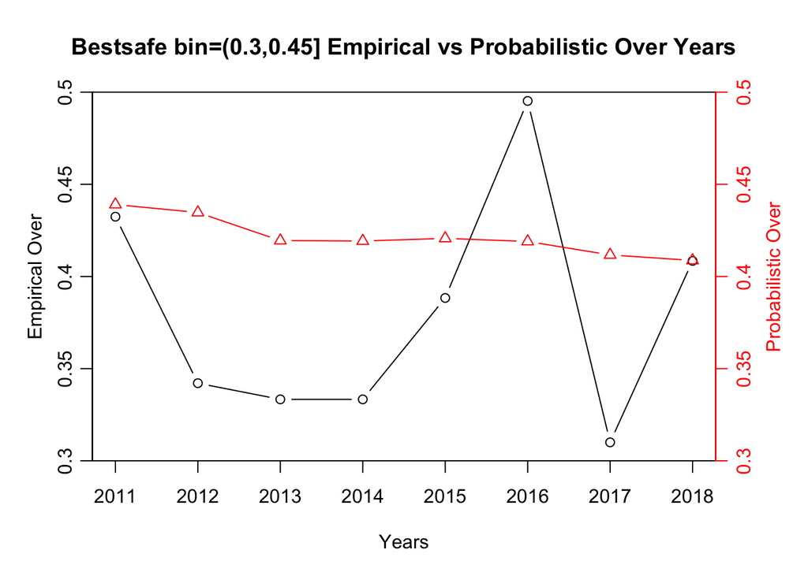

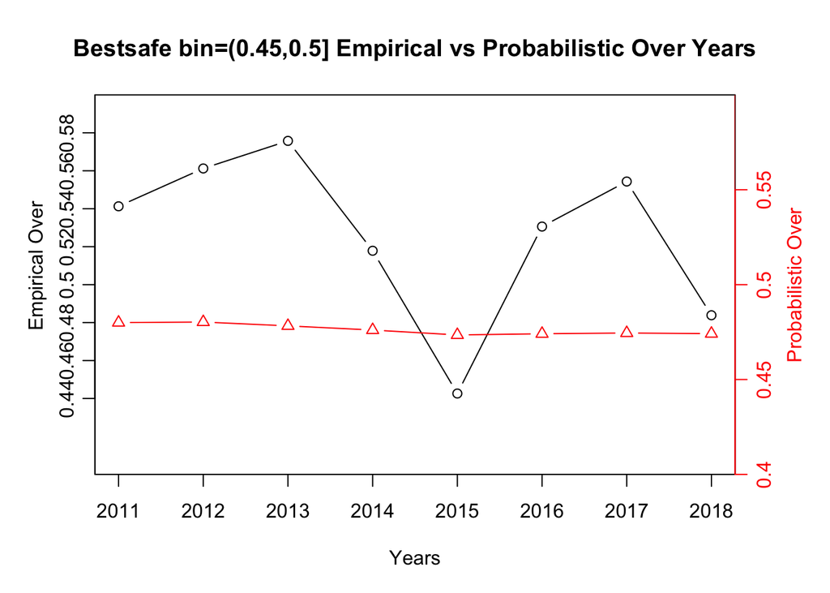

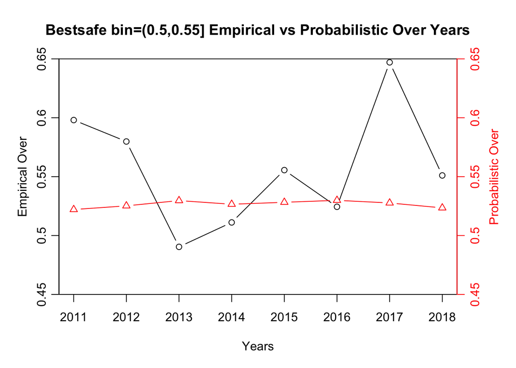

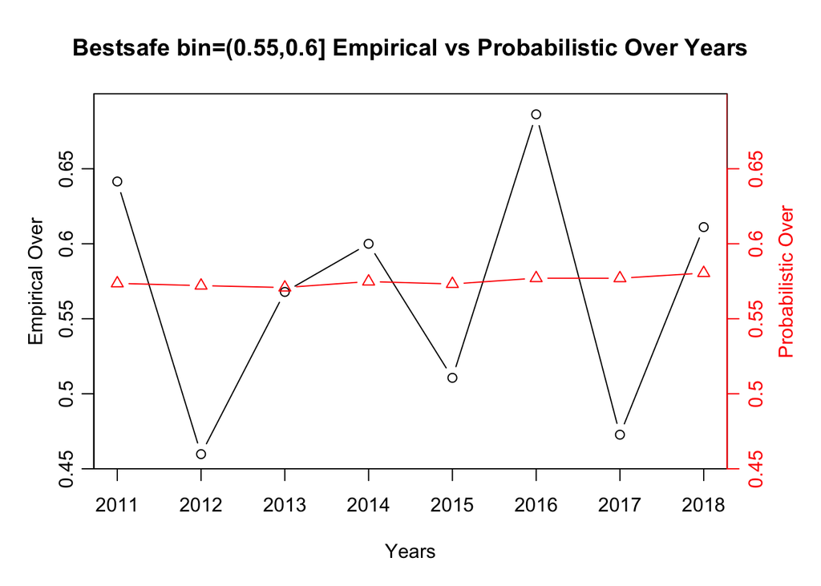

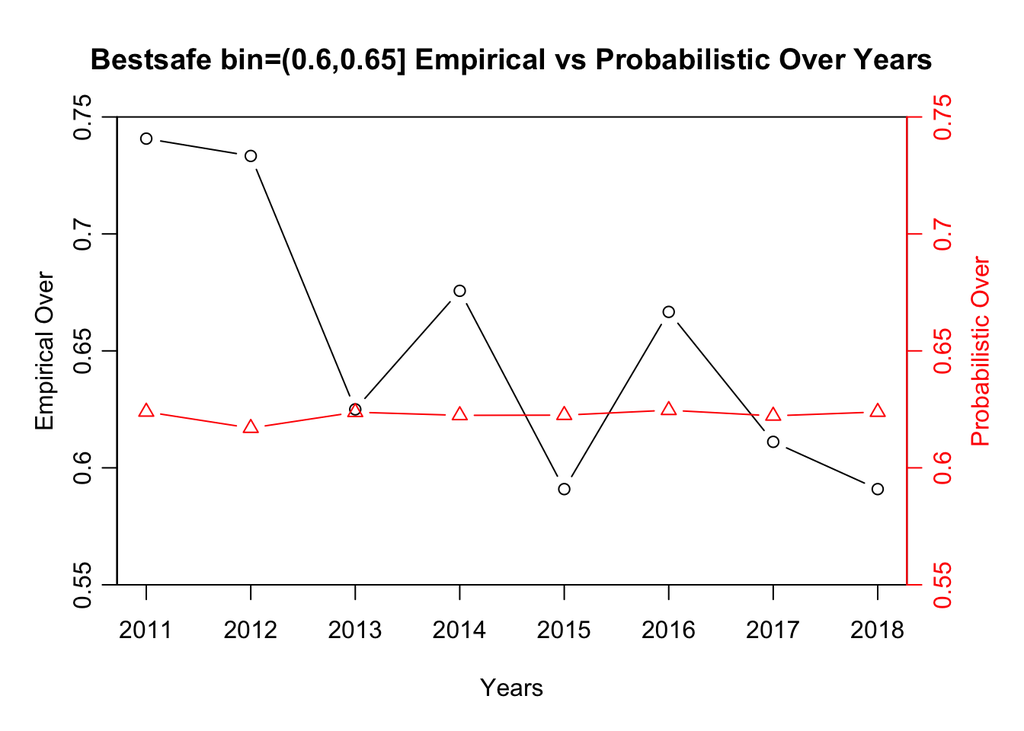

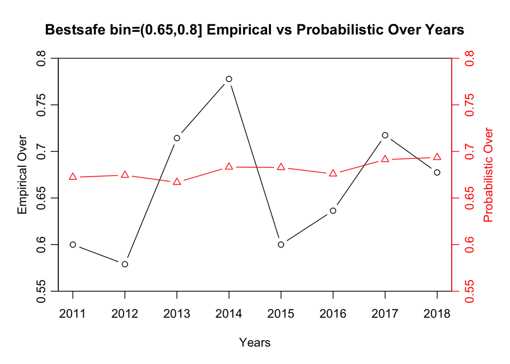

Based on the graphs we can say that Betsafe is not consistently good at determining over probabilities.

To say that they are consistently good at determining we have to observe that Black and Red lines have the same pattern, but they do not have same pattern. So, they are not good at determining over probabilities by years

## Task 2- Does odd changes have any information?

Youwin is selected for further investigation, so the data is filtered and unnecessary parts are removed. Date is converted to real date. The data is ordered based on matchId and time.

```r
odds_bet_type_1X2=odd_details[betType=="1x2" &bookmaker=='youwin']
odds_bet_type_1X2=odds_bet_type_1X2[,totalhandicap:=NULL]
odds_bet_type_1X2[,match_time:=anytime(date)]
odds_bet_type_1X2=odds_bet_type_1X2[order(matchId,match_time)]
```

We need the information from matches data table, so the tables are merged based on unique match IDs.

```r
merged_bet_type_1X2=merge(DT_matches,odds_bet_type_1X2,by="matchId")
```

The table includes the information of number of odds for the specific match under the column name “count” and total scores under the “sum_scores” column which have total score of the matches.

```r
table_bet_type_1X2=merged_bet_type_1X2[,list(count=.N, sum_scores=mean(Sum_score)),
                                       by=list(matchId)]
```

Plot is created to show the relation between number of changes and the total score.

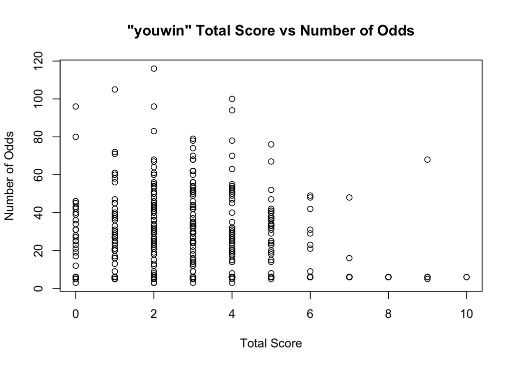

```r
plot(table_bet_type_1X2[,count,sum_scores], main='"youwin" Total Score vs Number of Odds',
                                            xlab='Total Score',ylab='Number of Odds')
```